# Unit09HW

Mark Mastrangeli

10/28/2018

Questions

Background: Brewmeisters in Colorado and Texas have teamed up to analyze the relationship between ABV and IBU in each of their states. Use the data sets from the project to help them in their analysis. There three main questions of interest are 1) Is there a significant linear relationship between ABV (response) and IBU (explanatory), 2) Is this relationship different between beers in Colorado and Texas and 3) Is there a significant quadratic component in this relationship for either Colorado or Texas or both?

A. Clean an prepare the data: 1. Create column for brewery ID that is common to both datasets similar to what you did in the project. So we can merge! 2. Merge the beer and brewery data into a single dataframe. 3. Clean the State Column … get rid of extraneous white space.  
4. Create One Dataset that has only Colorado and Texas beers and no IBU NAs … name it “beerCOTX” 5. Order beerCOTX by IBU (ascending) … this will be important later in graphing

```r
Beers <- read_csv("Beers.csv", col_names = TRUE, trim_ws = TRUE, na = c("", "NA"), quoted_na = TRUE)
#View(Beers)
Breweries <- read_csv("Breweries.csv", col_names = TRUE, trim_ws = TRUE, na = c("", "NA"), quoted_na = TRUE)
#View(Breweries)
#View(table(Breweries$State))
Breweries_Beers <- merge(Beers, Breweries, by.x = ("Brewery_id"), by.y = ("Brew_ID"), sort = TRUE)
#colSums(is.na(Breweries_Beers))
#View(Breweries_Beers)
#head(Breweries_Beers, 6)
#tail(Breweries_Beers, 6)
Breweries_Beers <- as.data.frame(Breweries_Beers)
colnames(Breweries_Beers) <- c("Brewery_ID", "Beer_Name", "Beer_ID", "ABV", "IBU", "Style", "Ounces", "Brewery_Name", "City", "State")

COTX <- c("CO", "TX")
beerCOTX <- subset.data.frame(Breweries_Beers, (State %in% COTX))

beerCOTX <- subset(beerCOTX, !is.na(IBU))
beerCOTXCount <- count(beerCOTX, vars = beerCOTX$State)
colnames(beerCOTXCount) <- c("State", "BeerCount")
beerCOTX <- beerCOTX[order(beerCOTX$IBU),]
beerTX <- subset.data.frame(beerCOTX, (State %in% "TX"))
beerCO <- subset.data.frame(beerCOTX, (State %in% "CO"))

State_ABV_Median <- tapply(Breweries_Beers$ABV, Breweries_Beers$State, median, na.rm = TRUE)
#State_ABV_Median
State_IBU_Median <- tapply(Breweries_Beers$IBU, Breweries_Beers$State, median, na.rm = TRUE)
#State_IBU_Median
MaxABV <- max(Breweries_Beers$ABV, na.rm = TRUE)
#MaxABV
MaxIBU <- max(Breweries_Beers$IBU, na.rm = TRUE)
#MaxIBU
ABV_State <- tapply(Breweries_Beers$ABV, Breweries_Beers$State, median, na.rm = TRUE)
#ABV_State
IBU_State <- tapply(Breweries_Beers$IBU, Breweries_Beers$State, median, na.rm = TRUE)
#IBU_State
```

## B. Create an initial plots of the data

*6. Plot ABV v. IBU for both Colorado and Texas (two separate plots) … use ggplot and facets. ##C. Model the data* 7. For each state, fit a simple linear regression model (Model 1: ABV= β_0+β_1 IBU) to assess the relationship between ABV and IBU. Use the regular plot function in base R (not ggplot) to create a scatter plot with the regression line superimposed on the plot. Again, this should be done for each state.

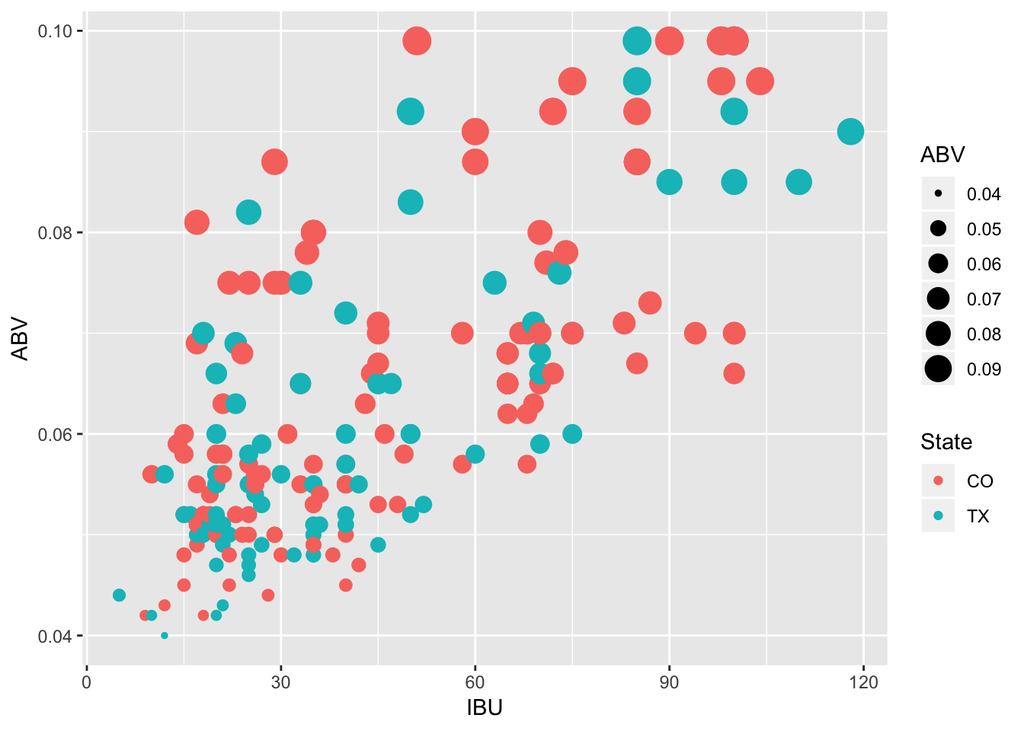

```r
CO_Count <- as.integer(146)
TX_Count <- as.integer(89)

CO_ABV_Median <- tapply(beerCO$ABV, beerCO$State, median, na.rm = TRUE)
CO_IBU_Median <- tapply(beerCO$IBU, beerCO$IBU, median, na.rm = TRUE)
CO_ABV_Max <- max(beerCO$ABV, na.rm = TRUE)
CO_IBU_Max <- max(beerCO$IBU, na.rm = TRUE)
TX_ABV_Median <- tapply(beerTX$ABV, beerTX$State, median, na.rm = TRUE)
TX_IBU_Median <- tapply(beerTX$IBU, beerTX$State, median, na.rm = TRUE)
TX_ABV_Max <- max(beerTX$ABV, na.rm = TRUE)
TX_IBU_Max <- max(beerTX$IBU, na.rm = TRUE)
COTX_ABV_Median <- tapply(beerCOTX$ABV, beerCOTX$State, median, na.rm = TRUE)
COTX_IBU_Median <- tapply(beerCOTX$IBU, beerCOTX$State, median, na.rm = TRUE)
COTX_ABV_Max <- max(beerCOTX$ABV, na.rm = TRUE)
COTX_IBU_Max <- max(beerCOTX$IBU, na.rm = TRUE)


COfit = lm(beerCO$ABV ~ beerCO$IBU + beerCO$IBU,data = beerCO) # fit the model to get Beta_hat_0 and Beta_hat_1
COcoefs <- coef(COfit)
COSummary <- summary(COfit) # view the parameter estimate table
COfit_r2 <- c("0.4433")
COsigma <- sigma(COfit)
TXfit = lm(beerTX$ABV ~ beerTX$IBU + beerTX$IBU,data = beerTX) # fit the model to get Beta_hat_0 and Beta_hat_1
TXcoefs <- coef(TXfit)
TXSummary <- summary(TXfit) # view the parameter estimate table
TXfit_r2 <- c("0.596")
TXsigma <- sigma(TXfit)
COTXfit = lm(beerCOTX$ABV ~ beerCOTX$IBU + beerCOTX$IBU,data = beerCOTX) # fit the model to get Beta_hat_0 and Beta_hat_1
COTXcoefs <- coef(COTXfit)
COTXSummary <- summary(COTXfit) # view the parameter estimate table
COTXfit_r2 <- c("0.5061")
COTXsigma <- sigma(COTXfit)

p <- ggplot(beerCOTX, aes(x=IBU, y=ABV, colour=State, size=ABV)) + geom_point()
p
```

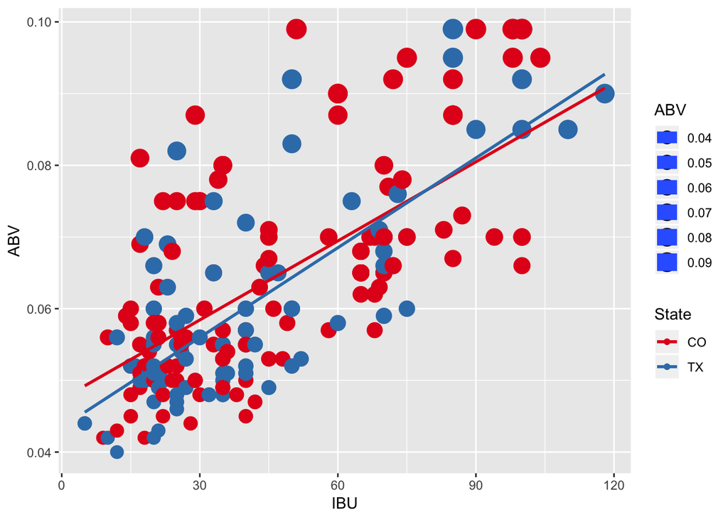

```r
p + stat_smooth(method = lm, se = FALSE, fullrange = TRUE, level = 0.99) + scale_shape_manual(values = c(20,20)) + scale_size_area() + scale_color_brewer(palette = "Set1")
```

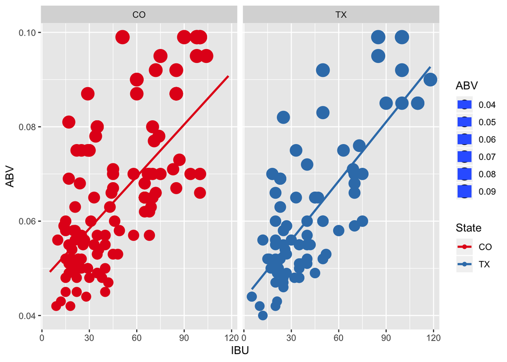

```r
p + stat_smooth(method = lm, se = FALSE, fullrange = TRUE, level = 0.99) +scale_shape_manual(values = c(20,20)) + scale_size_area() + scale_color_brewer(palette = "Set1") + facet_wrap( ~ State)
```

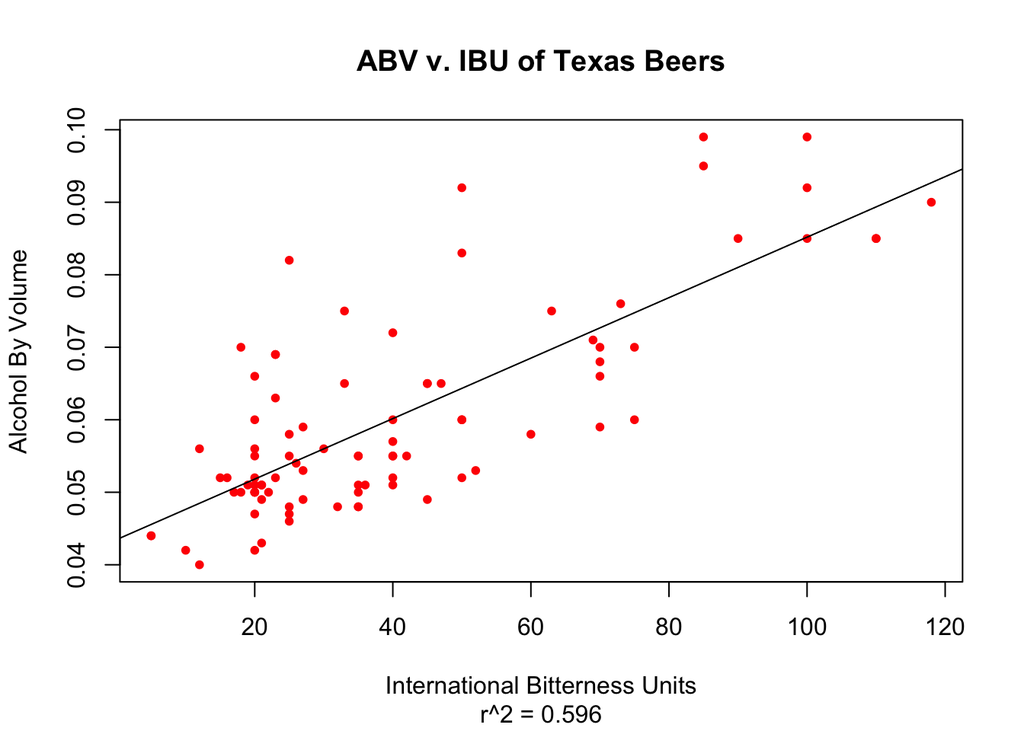

```r
#barplot(beerCOTX$IBU)




plot(beerTX$IBU,beerTX$ABV, pch = 20, col = "red", xlab = "International Bitterness Units", ylab ="Alcohol By Volume", main = "ABV v. IBU of Texas Beers", sub = "r^2 = 0.596")
abline(TXcoefs[1], TXcoefs[2])
```

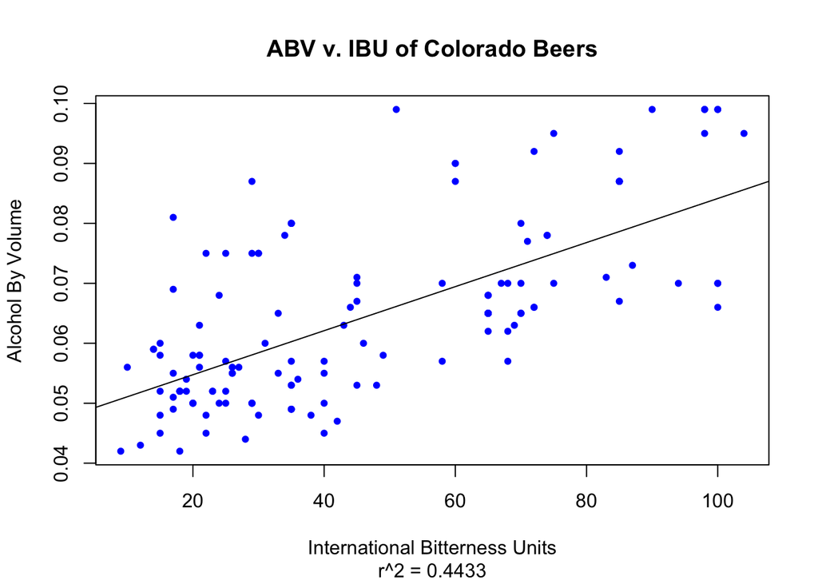

```r
TXsigma <- sigma(TXfit)

plot(beerCO$IBU,beerCO$ABV, pch = 20, col = "blue", xlab = "International Bitterness Units", ylab = "Alcohol By Volume", main = "ABV v. IBU of Colorado Beers", sub = "r^2 = 0.4433")
abline(COcoefs[1], COcoefs[2])
```

[figure not shown]

```r
plot(beerCOTX$ABV,beerCOTX$IBU, pch = 20, col = "blue", xlab = "International Bitterness Units", ylab = "Alcohol By Volume", main = "ABV v. IBU of Texas and Colorado Beers", sub = "r^2 = 0.5061")
abline(COTXcoefs[1], COTXcoefs[2])
```

```r
TX_Confidence <- data.frame(ABV =.1)
predict(TXfit, newdata = TX_Confidence, interval = 'confidence')
```

```
##           fit        lwr        upr
## 1  0.04555967 0.04233954 0.04877980
## 2  0.04555967 0.04233954 0.04877980
## 3  0.04764569 0.04471193 0.05057945
## 4  0.04848009 0.04565573 0.05130446
## 5  0.04848009 0.04565573 0.05130446
## 6  0.04973170 0.04706477 0.05239863
## 7  0.05014891 0.04753246 0.05276535
## 8  0.05056611 0.04799905 0.05313316
## 9  0.05098331 0.04846449 0.05350213
## 10 0.05098331 0.04846449 0.05350213
## 11 0.05140051 0.04892870 0.05387233
## 12 0.05181772 0.04939161 0.05424382
## 13 0.05181772 0.04939161 0.05424382
## 14 0.05181772 0.04939161 0.05424382
```

[output cut: 75 more lines]

```r
COTX_Confidence <- data.frame(ABV=.1)
predict(COTXfit, newdata = COTX_Confidence, interval = 'confidence')
```

```
##            fit        lwr        upr
## 1   0.04758686 0.04521239 0.04996134
## 2   0.04758686 0.04521239 0.04996134
## 3   0.04915009 0.04693922 0.05136095
## 4   0.04954090 0.04737000 0.05171179
## 5   0.04954090 0.04737000 0.05171179
## 6   0.05032251 0.04823028 0.05241474
## 7   0.05032251 0.04823028 0.05241474
## 8   0.05032251 0.04823028 0.05241474
## 9   0.05110412 0.04908870 0.05311954
## 10  0.05110412 0.04908870 0.05311954
## 11  0.05149493 0.04951715 0.05347271
## 12  0.05149493 0.04951715 0.05347271
## 13  0.05149493 0.04951715 0.05347271
## 14  0.05149493 0.04951715 0.05347271
```

[output cut: 221 more lines]

```r
CO_Confidence <- data.frame(ABV=.1)
predict(COfit, newdata = CO_Confidence, interval = 'confidence')
```

```
##            fit        lwr        upr
## 1   0.05070938 0.04756249 0.05385626
## 2   0.05107695 0.04798604 0.05416786
## 3   0.05181208 0.04883165 0.05479252
## 4   0.05254722 0.04967510 0.05541934
## 5   0.05254722 0.04967510 0.05541934
## 6   0.05291479 0.05009594 0.05573365
## 7   0.05291479 0.05009594 0.05573365
## 8   0.05291479 0.05009594 0.05573365
## 9   0.05291479 0.05009594 0.05573365
## 10  0.05291479 0.05009594 0.05573365
## 11  0.05364993 0.05093566 0.05636420
## 12  0.05364993 0.05093566 0.05636420
## 13  0.05364993 0.05093566 0.05636420
## 14  0.05364993 0.05093566 0.05636420
```

[output cut: 132 more lines]

*8. Address the assumptions of the regression model.  
You may assume the data are independent (even if this is a stretch.):  
**1. There is a normal distribution of the ABV for fixed values of IBU.

**2. These normal distributions have equal standard deviations.**  
3. The means of these normal distributions have a linear relationship with IBU.  
**4. Independence ( you may assume this one to be true without defense.)